# microreact data

##The Data

```r
library(readr)
library(tidyverse)
library(janitor)
library(here)
library(naniar)
library(ggthemes)
library(shiny)
library(shinydashboard)
library(viridis)
microreact<- read_csv("Data/microreact_isolates.csv")
microreact <- janitor::clean_names(microreact)
View(microreact)
```

```r
library(paletteer)
colors <- paletteer::palettes_d_names
my_palette <- paletteer_d("calecopal::kelp2")
```

```r
summary(microreact)
```

```
##       id               latitude         longitude          clade
##  Length:305         Min.   :-28.817   Min.   :-118.76   Length:305
##  Class :character   1st Qu.:  4.598   1st Qu.: -74.08   Class :character
##  Mode  :character   Median : 10.980   Median : -71.64   Mode  :character
##                     Mean   : 19.756   Mean   : -22.90
##                     3rd Qu.: 39.784   3rd Qu.:  38.43
##                     Max.   : 55.367   Max.   : 139.24
##
##  clade_colour         country          country_colour          year
##  Length:305         Length:305         Length:305         Min.   :2004
##  Class :character   Class :character   Class :character   1st Qu.:2014
##  Mode  :character   Mode  :character   Mode  :character   Median :2016
##                                                           Mean   :2015
##                                                           3rd Qu.:2016
##                                                           Max.   :2018
##
##      month             day           fcz             fcz_colour
##  Min.   : 1.000   Min.   : 1.0   Length:305         Length:305
##  1st Qu.: 4.000   1st Qu.:11.0   Class :character   Class :character
##  Median : 7.000   Median :15.0   Mode  :character   Mode  :character
##  Mean   : 6.914   Mean   :15.7
##  3rd Qu.: 9.000   3rd Qu.:21.0
##  Max.   :28.000   Max.   :30.0
##  NA's   :1
##      amb             amb_colour            mcf             mcf_colour
##  Length:305         Length:305         Length:305         Length:305
##  Class :character   Class :character   Class :character   Class :character
##  Mode  :character   Mode  :character   Mode  :character   Mode  :character
##
##
##
##
##     erg11           erg11_colour           fks1           fks1_colour
##  Length:305         Length:305         Length:305         Length:305
##  Class :character   Class :character   Class :character   Class :character
##  Mode  :character   Mode  :character   Mode  :character   Mode  :character
##
##
##
##
```

- What I want to look at:
  - incidence of cases by year and by country
  - incidence of AMR genes over time
    - Convert my categorical data to continuous w/`count`
  - map of outbreaks and appearance of resistance
    - Find relationship between resistance emergence and *C.auris* emergence
- More data that I want to find more of:
  - More info on AMR resistance genes
    - Info on genotypes (specifically ERG11 & FKS1 genes)
    - Info on prevalence

## Cases by year and by country:

- For abx resistance specifically?
- make bar plot for each country and facet grid by year?
- make a line graph by year for each country and facet that?
  - Too many countries for that-=8

```r
case_counts <- microreact %>%
  count(country, year)
```

Mutating Data for showing resistance: add column: - NR: Not resistant to FCZ or MCF (both == “Not_Resistant”) - FCZ: Resistant to FCZ but not MCF or AMB - MCF: Resistant to MCF but not FCZ or AMB - AMB: Resistant to AMB not MCF or FCZ - MDR: Resisant to 2/3 drugs - XDR: Resistant to AMB, FCZ, and MCF (both== “Resistant”)

*** Want to make graph of case#’s of these to show AMR resistance increase

```r
#Here I am adding a column that codes for type of drug resistance

microreact_drug_resistance <- microreact %>%
  mutate( drug_resistance = case_when(
    fcz=="Not_Resistant"& mcf=="Not_Resistant"& amb=="Not_Resistant" ~ "NR",
    fcz=="Resistant"& mcf=="Not_Resistant"& amb=="Not_Resistant" ~ "FCZ",
    fcz=="Not_Resistant" & mcf=="Resistant" & amb=="Not_Resistant" ~ "MCF",
    fcz=="Not_Resistant" & mcf=="Not_Resistant" & amb=="Resistant" ~ "AMB",

    fcz=="Resistant"& mcf=="Resistant"& amb=="Not_Resistant" ~ "MDR",
    fcz=="Resistant"& mcf=="Not_Resistant"& amb=="Resistant" ~ "MDR",
    fcz=="Not_Resistant"& mcf=="Resistant"& amb=="Resistant" ~ "MDR",

    fcz=="Resistant"& mcf=="Resistant"& amb=="Resistant" ~ "XDR"



  ))
```

Mutating data for showing ERG11 and FKS1 gene presence: - ERG11: `erg11`!= “WT” , `fks1`==“WT” - FSK1: `fsk1` !=“WT”, `erg11`== “WT” - ERG11 and FKS1: `erg11`!= “WT”, `fsk1` !=“WT” _ No AMR genes: `fks1`==“WT”, erg11`== “WT”

*** Make Venn Diagram: show relation of erg11 and fsk1 to drug resistance

```r
#Here I am adding another column that codes for presence or absence of known drug resistance genes

microreact_drug_resistance <- microreact_drug_resistance %>%
  mutate( amr_gene = case_when(
    erg11 != "WT" & fks1=="WT" ~ "ERG11",
    fks1 !="WT"& erg11 == "WT" ~ "FKS1",
    erg11 != "WT" & fks1 !="WT" ~ "ERG11 & FKS1",
    fks1 =="WT" & erg11 == "WT" ~ "No AMR genes"


))
```

Venn Diagram: showing AMR genes that are associated with drug resistance:

```r
library(ggVennDiagram)
```

combine 2 genes into 1 and get rid of SDR

```r
#my questions: Does having an AMR gene correlate with drug resistance?

#First I need to make the vectors

#vectors for drug resistance:

one_drug_resistant_vec <-
  microreact_drug_resistance %>%
  filter(drug_resistance== "FCZ"|drug_resistance=="AMB"|drug_resistance=="MCF") %>%
  pull(id)

mdr_resistant_vec <- microreact_drug_resistance %>%
  filter(drug_resistance=="MDR") %>%
  pull(id)

xdr_resistant_vec <- microreact_drug_resistance %>%
  filter(drug_resistance=="XDR") %>%
  pull(id)

no_resistance_vec <- microreact_drug_resistance %>%
  filter(drug_resistance=="NR") %>%
  pull(id)

#vectors for genes:

single_gene_vec <- microreact_drug_resistance %>%
  filter(amr_gene=="FKS1"|amr_gene=="ERG11") %>%
  pull(id)

combo_genes_vec <- microreact_drug_resistance %>%
  filter(amr_gene=="ERG11 & FKS1") %>%
  pull(id)

no_genes_vec <- microreact_drug_resistance %>%
  filter(amr_gene=="No AMR genes") %>%
  pull(id)

drug_gene_list <- list(mdr_resistant_vec, xdr_resistant_vec, no_resistance_vec, single_gene_vec, combo_genes_vec, no_genes_vec)
```

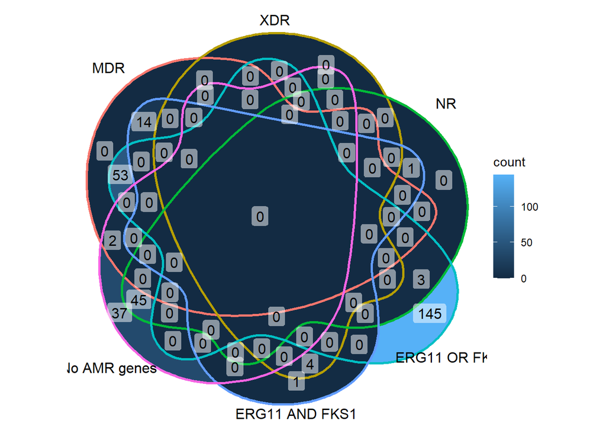

```r
ggVennDiagram(drug_gene_list,
              category.names=c("MDR", "XDR", "NR", "ERG11 OR FKS1", "ERG11 AND FKS1", "No AMR genes"),
              label="count"
              )
```

OK this is too complicated, need a different approach

Heat map:

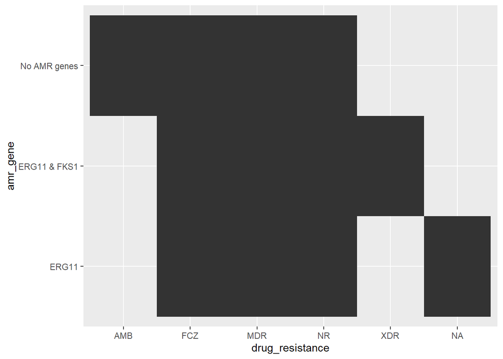

```r
microreact_drug_resistance %>%
  ggplot(aes(drug_resistance, amr_gene))+
  geom_tile()+
  scale_fill_viridis_b()
```

```r
library(ggplot2)
```

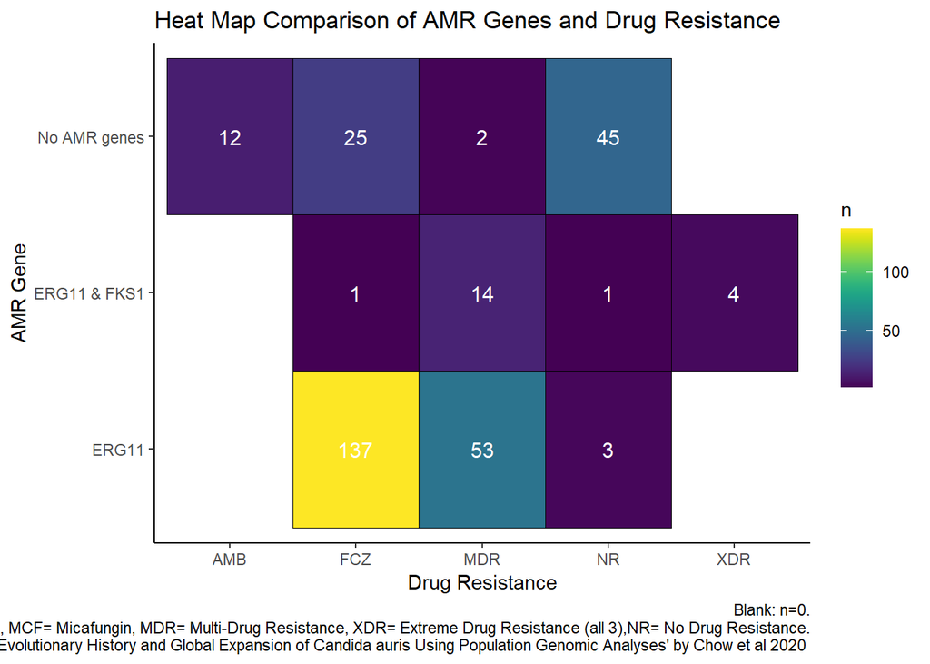

```r
microreact_drug_resistance %>%
  count(drug_resistance, amr_gene) %>%
  filter(drug_resistance!="NA") %>%
  ggplot(aes(drug_resistance, amr_gene, fill=n))+
  geom_tile(color="black")+
  geom_text(aes(label = n), color = "white", size = 4)+
  scale_fill_viridis()+
  theme_classic()+
  labs(title="Heat Map Comparison of AMR Genes and Drug Resistance",
       x="Drug Resistance",
       y="AMR Gene",
       caption="Blank: n=0.
       Drugs:AMB= Amphotericin B, FCZ= Fluconazole, MCF= Micafungin, MDR= Multi-Drug Resistance, XDR= Extreme Drug Resistance (all 3),NR= No Drug Resistance.
       Data from Tracing the Evolutionary History and Global Expansion of Candida auris Using Population Genomic Analyses' by Chow et al 2020 ")
```

```r
microreact_drug_resistance %>% count(drug_resistance, amr_gene)
```

```
## # A tibble: 12 x 3
##    drug_resistance amr_gene         n
##    <chr>           <chr>        <int>
##  1 AMB             No AMR genes    12
##  2 FCZ             ERG11          137
##  3 FCZ             ERG11 & FKS1     1
##  4 FCZ             No AMR genes    25
##  5 MDR             ERG11           53
##  6 MDR             ERG11 & FKS1    14
##  7 MDR             No AMR genes     2
##  8 NR              ERG11            3
##  9 NR              ERG11 & FKS1     1
## 10 NR              No AMR genes    45
## 11 XDR             ERG11 & FKS1     4
## 12 <NA>            ERG11            8
```

- From this heat map and table we can see that the ERG11 gene has a lot of overlap with drug resistance- both SDR and MDR
- We can also see that cases with no AMR genes also have more cases without drug resistance

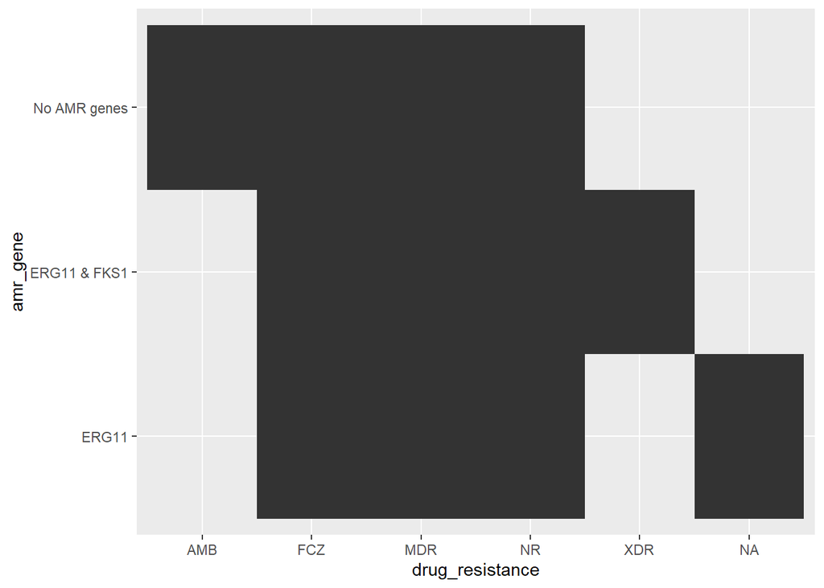

```r
microreact_drug_resistance %>%
  ggplot(aes(drug_resistance, amr_gene))+
  geom_tile()+
  scale_fill_viridis_b()
```